# World Population

## 1. Introduction

The World Population Data dataset provides total population statistics for each country from 1960 to 2020, as well as some additional information by country, such as its region, income group, and special notes (if any).

The dataset can be found [here](https://www.datacamp.com/workspace/datasets/dataset-r-world-population)

## 2. Setting up my environment

Load the ‘tidyverse’ package

```r
library(tidyverse)
```

Import the dataset

```r
world_pop <- read_csv("world_pop_data.csv")
country <- read_csv("metadata_country.csv")
```

View the tables

```r
head(world_pop)
```

```
## # A tibble: 6 × 64
##   `Country Code` `Indicator Name`   `Indicator Code` `1960` `1961` `1962` `1963`
##   <chr>          <chr>              <chr>             <dbl>  <dbl>  <dbl>  <dbl>
## 1 ABW            "\"Population, to… SP.POP.TOTL      5.42e4 5.54e4 5.62e4 5.67e4
## 2 AFE            "\"Population, to… SP.POP.TOTL      1.31e8 1.34e8 1.38e8 1.41e8
## 3 AFG            "\"Population, to… SP.POP.TOTL      9.00e6 9.17e6 9.35e6 9.54e6
## 4 AFW            "\"Population, to… SP.POP.TOTL      9.64e7 9.84e7 1.01e8 1.03e8
## 5 AGO            "\"Population, to… SP.POP.TOTL      5.45e6 5.53e6 5.61e6 5.68e6
## 6 ALB            "\"Population, to… SP.POP.TOTL      1.61e6 1.66e6 1.71e6 1.76e6
## # ℹ 57 more variables: `1964` <dbl>, `1965` <dbl>, `1966` <dbl>, `1967` <dbl>,
## #   `1968` <dbl>, `1969` <dbl>, `1970` <dbl>, `1971` <dbl>, `1972` <dbl>,
## #   `1973` <dbl>, `1974` <dbl>, `1975` <dbl>, `1976` <dbl>, `1977` <dbl>,
## #   `1978` <dbl>, `1979` <dbl>, `1980` <dbl>, `1981` <dbl>, `1982` <dbl>,
## #   `1983` <dbl>, `1984` <dbl>, `1985` <dbl>, `1986` <dbl>, `1987` <dbl>,
## #   `1988` <dbl>, `1989` <dbl>, `1990` <dbl>, `1991` <dbl>, `1992` <dbl>,
## #   `1993` <dbl>, `1994` <dbl>, `1995` <dbl>, `1996` <dbl>, `1997` <dbl>, …
```

```r
head(country)
```

```
## # A tibble: 6 × 5
##   `Country Code` Region                    IncomeGroup    SpecialNotes TableName
##   <chr>          <chr>                     <chr>          <chr>        <chr>
## 1 ABW            Latin America & Caribbean High income    "null"       Aruba
## 2 AFE            null                      null           "\"26 count… Africa E…
## 3 AFG            South Asia                Low income     "Fiscal yea… Afghanis…
## 4 AFW            null                      null           "\"22 count… Africa W…
## 5 AGO            Sub-Saharan Africa        Lower middle … "null"       Angola
## 6 ALB            Europe & Central Asia     Upper middle … "null"       Albania
```

Merge the two tables

```r
pop_and_country_wide <- merge(x=world_pop, y=country, by="Country Code", all.x=TRUE)
head(pop_and_country_wide)
```

```
##   Country Code      Indicator Name Indicator Code      1960      1961      1962
## 1          ABW "Population, total"    SP.POP.TOTL     54208     55434     56234
## 2          AFE "Population, total"    SP.POP.TOTL 130836765 134159786 137614644
## 3          AFG "Population, total"    SP.POP.TOTL   8996967   9169406   9351442
## 4          AFW "Population, total"    SP.POP.TOTL  96396419  98407221 100506960
## 5          AGO "Population, total"    SP.POP.TOTL   5454938   5531451   5608499
## 6          ALB "Population, total"    SP.POP.TOTL   1608800   1659800   1711319
##        1963      1964      1965      1966      1967      1968      1969
## 1     56699     57029     57357     57702     58044     58377     58734
## 2 141202036 144920186 148769974 152752671 156876454 161156430 165611760
## 3   9543200   9744772   9956318  10174840  10399936  10637064  10893772
## 4 102691339 104953470 107289875 109701811 112195950 114781116 117468741
## 5   5679409   5734995   5770573   5781305   5774440   5771973   5803677
## 6   1762621   1814135   1864791   1914573   1965598   2022272   2081695
##        1970      1971      1972      1973      1974      1975      1976
```

[output cut: 69 more lines]

```r
colnames(pop_and_country_wide)
```

```
##  [1] "Country Code"   "Indicator Name" "Indicator Code" "1960"
##  [5] "1961"           "1962"           "1963"           "1964"
##  [9] "1965"           "1966"           "1967"           "1968"
## [13] "1969"           "1970"           "1971"           "1972"
## [17] "1973"           "1974"           "1975"           "1976"
## [21] "1977"           "1978"           "1979"           "1980"
## [25] "1981"           "1982"           "1983"           "1984"
## [29] "1985"           "1986"           "1987"           "1988"
## [33] "1989"           "1990"           "1991"           "1992"
## [37] "1993"           "1994"           "1995"           "1996"
## [41] "1997"           "1998"           "1999"           "2000"
## [45] "2001"           "2002"           "2003"           "2004"
## [49] "2005"           "2006"           "2007"           "2008"
## [53] "2009"           "2010"           "2011"           "2012"
## [57] "2013"           "2014"           "2015"           "2016"
## [61] "2017"           "2018"           "2019"           "2020"
## [65] "Region"         "IncomeGroup"    "SpecialNotes"   "TableName"
```

Reshape the data from wide to long

```r
pop_and_country_long <- gather(pop_and_country_wide, Year, Population, `1960`:`2020`, factor_key = TRUE)
pop_and_country_long$Year=as.numeric(levels(pop_and_country_long$Year))[pop_and_country_long$Year]
head(pop_and_country_long)
```

```
##   Country Code      Indicator Name Indicator Code                    Region
## 1          ABW "Population, total"    SP.POP.TOTL Latin America & Caribbean
## 2          AFE "Population, total"    SP.POP.TOTL                      null
## 3          AFG "Population, total"    SP.POP.TOTL                South Asia
## 4          AFW "Population, total"    SP.POP.TOTL                      null
## 5          AGO "Population, total"    SP.POP.TOTL        Sub-Saharan Africa
## 6          ALB "Population, total"    SP.POP.TOTL     Europe & Central Asia
##           IncomeGroup
## 1         High income
## 2                null
## 3          Low income
## 4                null
## 5 Lower middle income
## 6 Upper middle income
##                                                                                                                                                                                                                            SpecialNotes
## 1                                                                                                                                                                                                                                  null
## 2                                                                  "26 countries, stretching from the Red Sea in the North to the Cape of Good Hope in the South (https://www.worldbank.org/en/region/afr/eastern-and-southern-africa)"
## 3                                                                                                                                                           Fiscal year end: March 20; reporting period for national accounts data: FY.
## 4 "22 countries, stretching from the westernmost point of Africa, across the equator, and partly along the Atlantic Ocean till the Republic of Congo in the South (https://www.worldbank.org/en/region/afr/western-and-central-africa)"
## 5                                                                                                                                                                                                                                  null
## 6                                                                                                                                                                                                                                  null
##                     TableName Year Population
## 1                       Aruba 1960      54208
## 2 Africa Eastern and Southern 1960  130836765
## 3                 Afghanistan 1960    8996967
## 4  Africa Western and Central 1960   96396419
## 5                      Angola 1960    5454938
## 6                     Albania 1960    1608800
```

## 3. Questions

### 3.1. How did the population of my country change over time?

Filter data

```r
japan_pop <- pop_and_country_long %>%
  filter(TableName == "Japan")
head(japan_pop)
```

```
##   Country Code      Indicator Name Indicator Code              Region
## 1          JPN "Population, total"    SP.POP.TOTL East Asia & Pacific
## 2          JPN "Population, total"    SP.POP.TOTL East Asia & Pacific
## 3          JPN "Population, total"    SP.POP.TOTL East Asia & Pacific
## 4          JPN "Population, total"    SP.POP.TOTL East Asia & Pacific
## 5          JPN "Population, total"    SP.POP.TOTL East Asia & Pacific
## 6          JPN "Population, total"    SP.POP.TOTL East Asia & Pacific
##   IncomeGroup
## 1 High income
## 2 High income
## 3 High income
## 4 High income
## 5 High income
## 6 High income
##                                                                  SpecialNotes
## 1 Fiscal year end: March 31; reporting period for national accounts data: CY.
## 2 Fiscal year end: March 31; reporting period for national accounts data: CY.
## 3 Fiscal year end: March 31; reporting period for national accounts data: CY.
## 4 Fiscal year end: March 31; reporting period for national accounts data: CY.
## 5 Fiscal year end: March 31; reporting period for national accounts data: CY.
## 6 Fiscal year end: March 31; reporting period for national accounts data: CY.
##   TableName Year Population
## 1     Japan 1960   93216000
## 2     Japan 1961   94055000
## 3     Japan 1962   94933000
## 4     Japan 1963   95900000
## 5     Japan 1964   96903000
## 6     Japan 1965   97952000
```

Create a plot

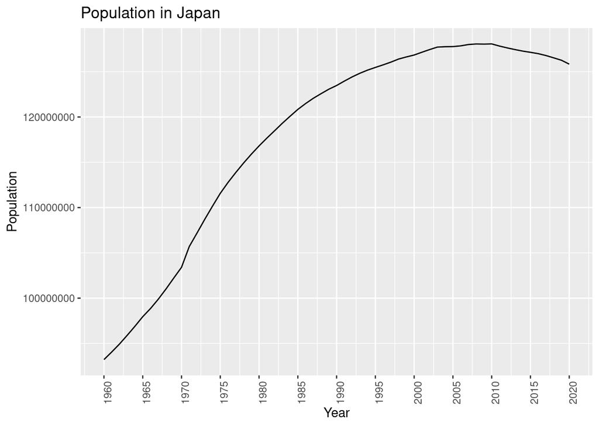

```r
options(scipen = 999)

ggplot(japan_pop, aes(x=Year, y=Population)) +
  geom_line() +
  scale_x_continuous(breaks = seq(1960, 2020, 5)) +
  scale_y_continuous(breaks = seq(0, 130000000, 10000000)) +
  theme(axis.text.x = element_text(angle = 90)) +
  ggtitle("Population in Japan")
```

### 3.2. How did the population in different parts of the world change over time?

Create a plot

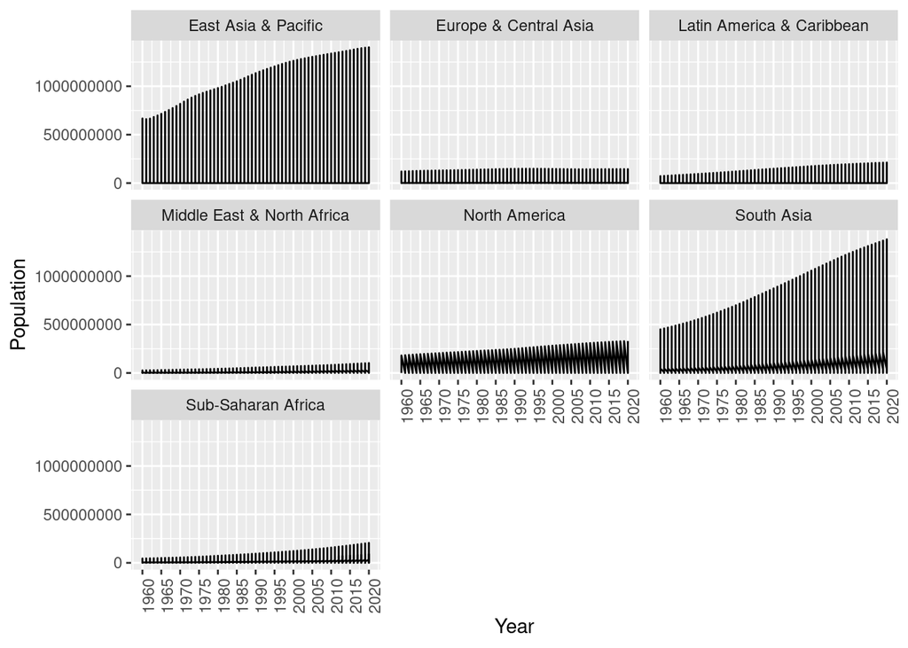

```r
pop_and_country_long %>%
  filter(Region != "null", Region != "NA") %>%
  ggplot(mapping = aes(x=Year, y=Population)) +
  geom_line() +
  scale_x_continuous(breaks = seq(1960, 2020, 5)) +
  theme(axis.text.x = element_text(angle = 90)) +
  facet_wrap(~ Region)
```

### 3.3. Which country or countries have experienced the highest increase/decrease in population over time?

Filter data

```r
pop_1960_2020 <- select(pop_and_country_wide, "Country Code", "TableName", "Region", "IncomeGroup", "1960", "2020")
glimpse(pop_1960_2020)
```

```
## Rows: 266
## Columns: 6
## $ `Country Code` <chr> "ABW", "AFE", "AFG", "AFW", "AGO", "ALB", "AND", "ARB",…
## $ TableName      <chr> "Aruba", "Africa Eastern and Southern", "Afghanistan", …
## $ Region         <chr> "Latin America & Caribbean", "null", "South Asia", "nul…
## $ IncomeGroup    <chr> "High income", "null", "Low income", "null", "Lower mid…
## $ `1960`         <dbl> 54208, 130836765, 8996967, 96396419, 5454938, 1608800, …
## $ `2020`         <dbl> 106766, 677243299, 38928341, 458803476, 32866268, 28377…
```

Add new columns to compare population in 1960 and in 2020

```r
pop_1960_2020 <- mutate(pop_1960_2020, divided = `2020` / `1960`, subtracted = `2020` - `1960`)
```

Highest population growth rate

```r
div_highest_1960_2020 <- arrange(pop_1960_2020, desc(divided))
head(div_highest_1960_2020, 20)
```

```
##    Country Code                 TableName                     Region
## 1           ARE      United Arab Emirates Middle East & North Africa
## 2           QAT                     Qatar Middle East & North Africa
## 3           KWT                    Kuwait Middle East & North Africa
## 4           SXM Sint Maarten (Dutch part)  Latin America & Caribbean
## 5           DJI                  Djibouti Middle East & North Africa
## 6           JOR                    Jordan Middle East & North Africa
## 7           BHR                   Bahrain Middle East & North Africa
## 8           MAF  St. Martin (French part)  Latin America & Caribbean
## 9           OMN                      Oman Middle East & North Africa
## 10          SAU              Saudi Arabia Middle East & North Africa
## 11          CYM            Cayman Islands  Latin America & Caribbean
## 12          CIV             Côte d'Ivoire         Sub-Saharan Africa
## 13          NER                     Niger         Sub-Saharan Africa
## 14          UGA                    Uganda         Sub-Saharan Africa
```

[output cut: 27 more lines]

Highest population growth number

```r
sub_highest_1960_2020 <- arrange(pop_1960_2020, desc(subtracted))
head(sub_highest_1960_2020, 20)
```

```
##    Country Code                                   TableName     Region
## 1           WLD                                       World       null
## 2           IBT                            IDA & IBRD total       null
## 3           LMY                         Low & middle income       null
## 4           MIC                               Middle income       null
## 5           IBD                                   IBRD only       null
## 6           EAR                  Early-demographic dividend       null
## 7           LMC                         Lower middle income       null
## 8           UMC                         Upper middle income       null
## 9           IDA                                   IDA total       null
## 10          EAS                         East Asia & Pacific       null
## 11          SAS                                  South Asia       null
## 12          TSA                     South Asia (IDA & IBRD)       null
## 13          LTE                   Late-demographic dividend       null
## 14          EAP East Asia & Pacific (excluding high income)       null
```

[output cut: 27 more lines]

Lowest population growth rate

```r
div_lowest_1960_2020 <- arrange(pop_1960_2020, divided)
head(div_lowest_1960_2020, 20)
```

```
##    Country Code                      TableName                    Region
## 1           BGR                       Bulgaria     Europe & Central Asia
## 2           LVA                         Latvia     Europe & Central Asia
## 3           HUN                        Hungary     Europe & Central Asia
## 4           HRV                        Croatia     Europe & Central Asia
## 5           LTU                      Lithuania     Europe & Central Asia
## 6           BIH         Bosnia and Herzegovina     Europe & Central Asia
## 7           GEO                        Georgia     Europe & Central Asia
## 8           UKR                        Ukraine     Europe & Central Asia
## 9           KNA            St. Kitts and Nevis Latin America & Caribbean
## 10          SRB                         Serbia     Europe & Central Asia
## 11          ROU                        Romania     Europe & Central Asia
## 12          EST                        Estonia     Europe & Central Asia
## 13          CZE                 Czech Republic     Europe & Central Asia
## 14          CEB Central Europe and the Baltics                      null
```

[output cut: 27 more lines]

Lowest population growth number

```r
sub_lowest_1960_2020 <- arrange(pop_1960_2020, subtracted)
head(sub_lowest_1960_2020, 20)
```

```
##    Country Code                      TableName                    Region
## 1           BGR                       Bulgaria     Europe & Central Asia
## 2           HUN                        Hungary     Europe & Central Asia
## 3           LVA                         Latvia     Europe & Central Asia
## 4           HRV                        Croatia     Europe & Central Asia
## 5           KNA            St. Kitts and Nevis Latin America & Caribbean
## 6           NRU                          Nauru       East Asia & Pacific
## 7           TUV                         Tuvalu       East Asia & Pacific
## 8           PLW                          Palau       East Asia & Pacific
## 9           GIB                      Gibraltar     Europe & Central Asia
## 10          DMA                       Dominica Latin America & Caribbean
## 11          FRO                  Faroe Islands     Europe & Central Asia
## 12          LTU                      Lithuania     Europe & Central Asia
## 13          MCO                         Monaco     Europe & Central Asia
## 14          SMR                     San Marino     Europe & Central Asia
```

[output cut: 27 more lines]

### 3.4. Which country or countries have been experiencing the highest increase/decrease in population in the last ten years?

Filter data

```r
pop_2010_2020 <- select(pop_and_country_wide, "Country Code", "TableName", "Region", "IncomeGroup", "2010", "2020")
glimpse(pop_2010_2020)
```

```
## Rows: 266
## Columns: 6
## $ `Country Code` <chr> "ABW", "AFE", "AFG", "AFW", "AGO", "ALB", "AND", "ARB",…
## $ TableName      <chr> "Aruba", "Africa Eastern and Southern", "Afghanistan", …
## $ Region         <chr> "Latin America & Caribbean", "null", "South Asia", "nul…
## $ IncomeGroup    <chr> "High income", "null", "Low income", "null", "Lower mid…
## $ `2010`         <dbl> 101665, 518468229, 29185511, 350556886, 23356247, 29130…
## $ `2020`         <dbl> 106766, 677243299, 38928341, 458803476, 32866268, 28377…
```

Add new columns to compare population in 2010 and in 2020

```r
pop_2010_2020 <- mutate(pop_2010_2020, divided = `2020` / `2010`, subtracted = `2020` - `2010`)
```

Highest population growth rate

```r
div_highest_2010_2020 <- arrange(pop_2010_2020, desc(divided))
head(div_highest_2010_2020, 20)
```

```
##    Country Code          TableName                     Region
## 1           OMN               Oman Middle East & North Africa
## 2           QAT              Qatar Middle East & North Africa
## 3           GNQ  Equatorial Guinea         Sub-Saharan Africa
## 4           MDV           Maldives                 South Asia
## 5           NER              Niger         Sub-Saharan Africa
## 6           KWT             Kuwait Middle East & North Africa
## 7           UGA             Uganda         Sub-Saharan Africa
## 8           AGO             Angola         Sub-Saharan Africa
## 9           JOR             Jordan Middle East & North Africa
## 10          COD "Congo, Dem. Rep."         Sub-Saharan Africa
## 11          LBN            Lebanon Middle East & North Africa
## 12          TCD               Chad         Sub-Saharan Africa
## 13          BHR            Bahrain Middle East & North Africa
## 14          BDI            Burundi         Sub-Saharan Africa
```

[output cut: 27 more lines]

Highest population growth number

```r
sub_highest_2010_2020 <- arrange(pop_2010_2020, desc(subtracted))
head(sub_highest_2010_2020, 20)
```

```
##    Country Code                                    TableName Region IncomeGroup
## 1           WLD                                        World   null        null
## 2           LMY                          Low & middle income   null        null
## 3           IBT                             IDA & IBRD total   null        null
## 4           MIC                                Middle income   null        null
## 5           LMC                          Lower middle income   null        null
## 6           IBD                                    IBRD only   null        null
## 7           EAR                   Early-demographic dividend   null        null
## 8           IDA                                    IDA total   null        null
## 9           SSF                           Sub-Saharan Africa   null        null
## 10          TSS              Sub-Saharan Africa (IDA & IBRD)   null        null
## 11          SSA   Sub-Saharan Africa (excluding high income)   null        null
## 12          PRE                     Pre-demographic dividend   null        null
## 13          IDX                                     IDA only   null        null
## 14          LDC Least developed countries: UN classification   null        null
```

[output cut: 27 more lines]

Lowest population growth rate

```r
div_lowest_2010_2020 <- arrange(pop_2010_2020, divided)
head(div_lowest_2010_2020, 20)
```

```
##    Country Code                      TableName                     Region
## 1           SYR           Syrian Arab Republic Middle East & North Africa
## 2           PRI                    Puerto Rico  Latin America & Caribbean
## 3           BIH         Bosnia and Herzegovina      Europe & Central Asia
## 4           LTU                      Lithuania      Europe & Central Asia
## 5           LVA                         Latvia      Europe & Central Asia
## 6           MDA                        Moldova      Europe & Central Asia
## 7           AND                        Andorra      Europe & Central Asia
## 8           BGR                       Bulgaria      Europe & Central Asia
## 9           HRV                        Croatia      Europe & Central Asia
## 10          SRB                         Serbia      Europe & Central Asia
## 11          ROU                        Romania      Europe & Central Asia
## 12          UKR                        Ukraine      Europe & Central Asia
## 13          GRC                         Greece      Europe & Central Asia
## 14          ALB                        Albania      Europe & Central Asia
```

[output cut: 27 more lines]

Lowest population growth number

```r
sub_lowest_2010_2020 <- arrange(pop_2010_2020, subtracted)
head(sub_lowest_2010_2020, 20)
```

```
##    Country Code                      TableName                     Region
## 1           SYR           Syrian Arab Republic Middle East & North Africa
## 2           JPN                          Japan        East Asia & Pacific
## 3           CEB Central Europe and the Baltics                       null
## 4           UKR                        Ukraine      Europe & Central Asia
## 5           ROU                        Romania      Europe & Central Asia
## 6           PRI                    Puerto Rico  Latin America & Caribbean
## 7           BGR                       Bulgaria      Europe & Central Asia
## 8           BIH         Bosnia and Herzegovina      Europe & Central Asia
## 9           GRC                         Greece      Europe & Central Asia
## 10          SRB                         Serbia      Europe & Central Asia
## 11          LTU                      Lithuania      Europe & Central Asia
## 12          PRT                       Portugal      Europe & Central Asia
## 13          HUN                        Hungary      Europe & Central Asia
## 14          HRV                        Croatia      Europe & Central Asia
```

[output cut: 27 more lines]